# Lab 4a

Jas Sur

2/27/2022

## Question 1

Setup data for pressure, temperature and yield

```r
temp.data <- rep(c(150,160,170), each=6)
pressure.data <- rep(c(200,215,230), each=3, times=2)
yield <- c(90.4, 90.2, 90.7,90.6,90.2,90.4,90.1,90.3,90.5,90.6,89.9,90.1,90.5,90.7,90.8,90.9,90.4,90.1)
chem.process <- data.frame(temp.data, pressure.data, yield)
attach(chem.process)
chem.process$temp <-factor(temp.data, levels =c(150,160,170), labels=c("150C", "160C", "170C"))
chem.process$pressure <-factor(pressure.data, levels =c(200,215,230), labels=c("200Psig","215Psig", "230Psig"))

head(chem.process)
```

|  | temp.data | pressure.data | yield | temp | pressure |
| --- | --- | --- | --- | --- | --- |
| 1 | 150 | 200 | 90.4 | 150C | 200Psig |
| 2 | 150 | 200 | 90.2 | 150C | 200Psig |
| 3 | 150 | 200 | 90.7 | 150C | 200Psig |
| 4 | 150 | 215 | 90.6 | 150C | 215Psig |
| 5 | 150 | 215 | 90.2 | 150C | 215Psig |
| 6 | 150 | 215 | 90.4 | 150C | 215Psig |

```r
str(chem.process)
```

```
## 'data.frame':    18 obs. of  5 variables:
##  $ temp.data    : num  150 150 150 150 150 150 160 160 160 160 ...
##  $ pressure.data: num  200 200 200 215 215 215 230 230 230 200 ...
##  $ yield        : num  90.4 90.2 90.7 90.6 90.2 90.4 90.1 90.3 90.5 90.6 ...
##  $ temp         : Factor w/ 3 levels "150C","160C",..: 1 1 1 1 1 1 2 2 2 2 ...
##  $ pressure     : Factor w/ 3 levels "200Psig","215Psig",..: 1 1 1 2 2 2 3 3 3 1 ...
```

```r
attach(chem.process)
```

### a. Analyze the data and draw conclusions, Use alpha = 0.05

a1. Plotting: boxplot of yield vs temp, yield vs pressure, yeld vs temp and pressure, interaction plot

```r
tapply(yield, list(temp,pressure), mean)
```

```
##       200Psig  215Psig  230Psig
## 150C 90.43333 90.40000       NA
## 160C 90.20000       NA 90.30000
## 170C       NA 90.66667 90.46667
```

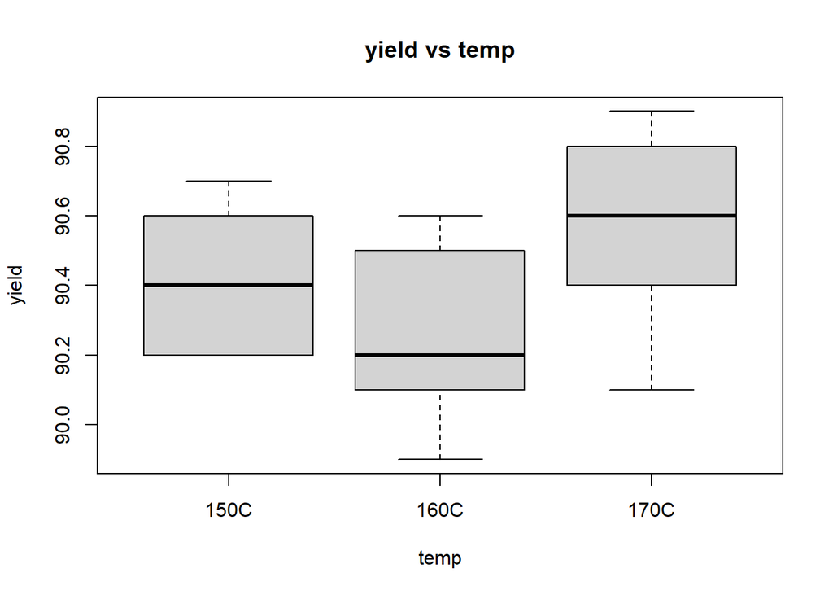

```r
boxplot(yield~temp, main="yield vs temp")
```

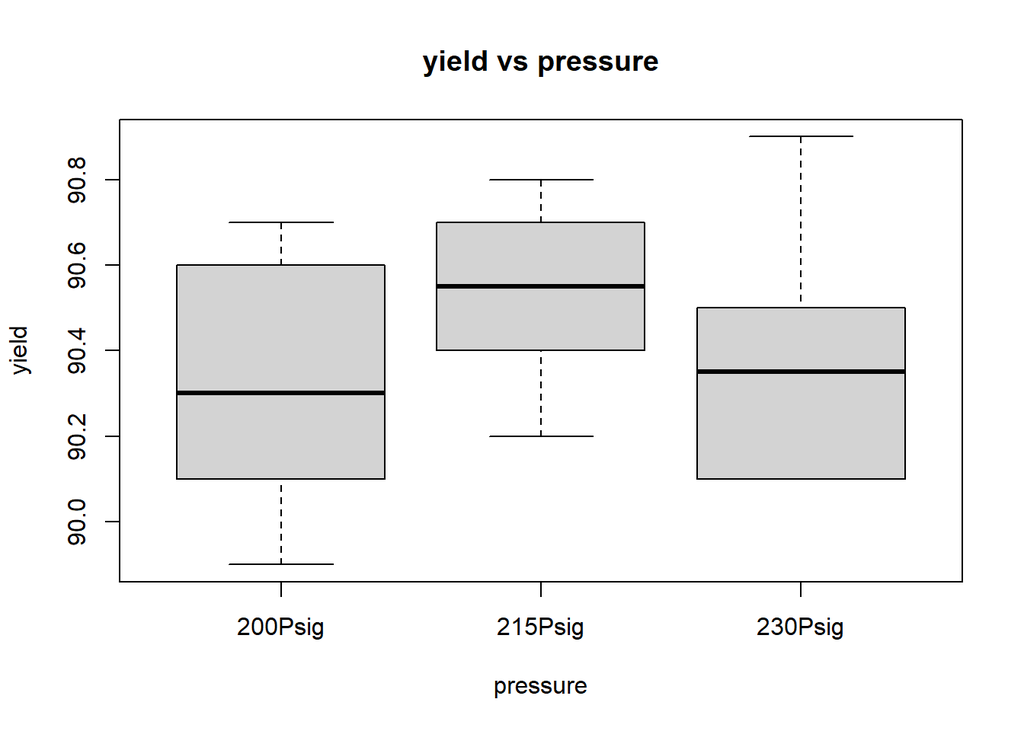

```r
boxplot(yield~pressure, main="yield vs pressure")
```

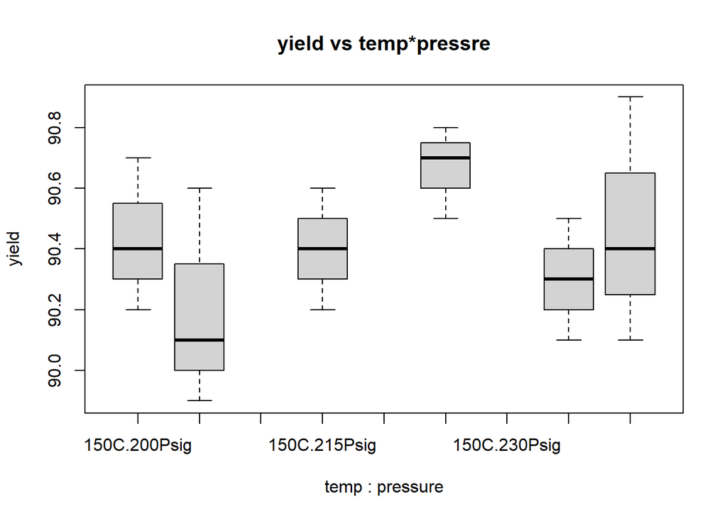

```r
boxplot(yield~temp*pressure, main="yield vs temp*pressre")
```

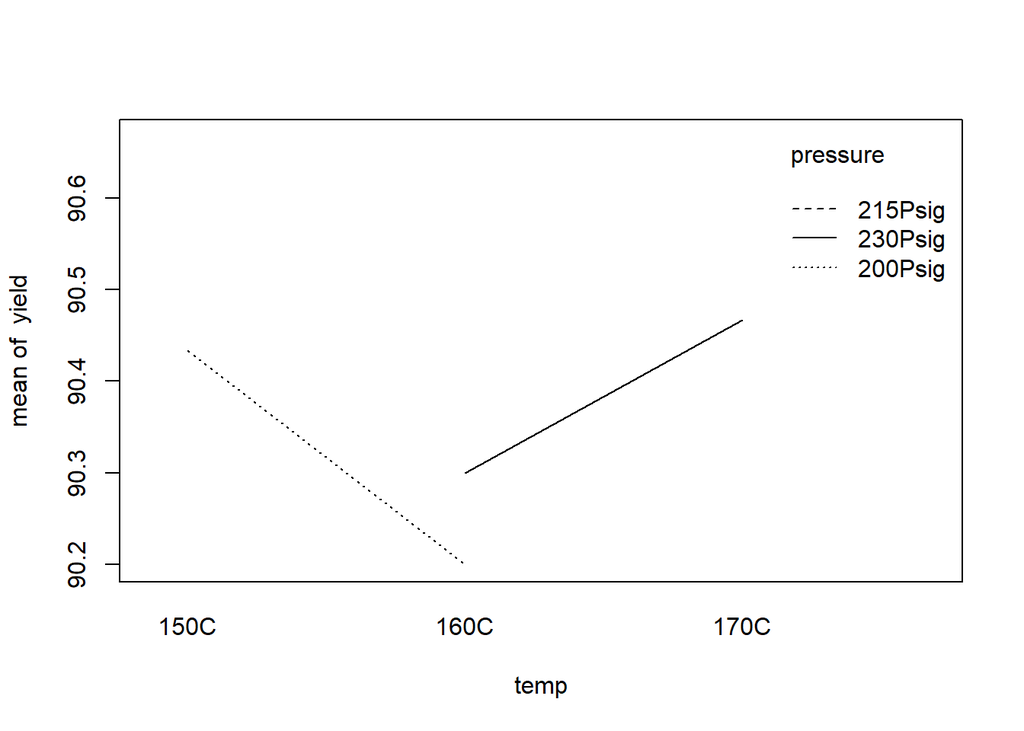

```r
interaction.plot(temp, pressure, yield)
```

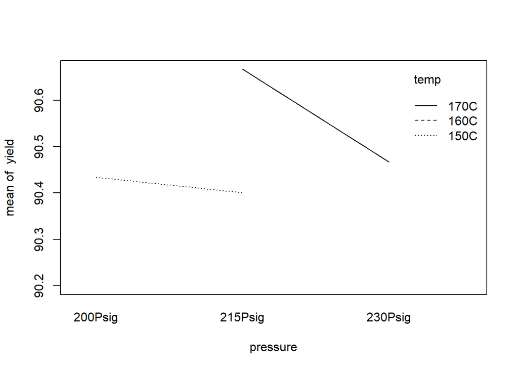

```r
interaction.plot(pressure, temp, yield)
```

Slopes are changing, so there is some kind of interaction

a2. Build a linear model using aov(). Print ANOVA output. Are main factors and interaction factor significant?

```r
chem.process.mod <- aov(yield~temp*pressure)
summary.aov(chem.process.mod)
```

```
##               Df Sum Sq Mean Sq F value Pr(>F)
## temp           2 0.3011 0.15056   1.964  0.183
## pressure       2 0.0211 0.01056   0.138  0.873
## temp:pressure  1 0.0556 0.05556   0.725  0.411
## Residuals     12 0.9200 0.07667
```

```r
summary.lm(chem.process.mod)
```

```
##
## Call:
## aov(formula = yield ~ temp * pressure)
##
## Residuals:
##      Min       1Q   Median       3Q      Max
## -0.36667 -0.19167 -0.01667  0.18333  0.43333
##
## Coefficients: (3 not defined because of singularities)
##                          Estimate Std. Error t value Pr(>|t|)
## (Intercept)              90.43333    0.15986 565.700   <2e-16 ***
## temp160C                 -0.23333    0.22608  -1.032    0.322
## temp170C                 -0.06667    0.31972  -0.209    0.838
## pressure215Psig          -0.03333    0.22608  -0.147    0.885
## pressure230Psig           0.10000    0.22608   0.442    0.666
## temp160C:pressure215Psig       NA         NA      NA       NA
## temp170C:pressure215Psig  0.33333    0.39158   0.851    0.411
## temp160C:pressure230Psig       NA         NA      NA       NA
## temp170C:pressure230Psig       NA         NA      NA       NA
## ---
## Signif. codes:  0 '***' 0.001 '**' 0.01 '*' 0.05 '.' 0.1 ' ' 1
##
## Residual standard error: 0.2769 on 12 degrees of freedom
## Multiple R-squared:  0.2911, Adjusted R-squared:  -0.004281
## F-statistic: 0.9855 on 5 and 12 DF,  p-value: 0.4657
```

```r
chem.process.nointeraction.mod <- aov(yield~temp+pressure)
anova(chem.process.mod, chem.process.nointeraction.mod)
```

|  | Res.Df | RSS | Df | Sum of Sq | F | Pr(>F) |
| --- | --- | --- | --- | --- | --- | --- |
| 1 | 12 | 0.9200000 | NA | NA | NA | NA |
| 2 | 13 | 0.9755556 | -1 | -0.05555556 | 0.7246377 | 0.4112923 |

Since P-value >.05, we accept null and reject Alternate. The interaction term is in-significant, so we can discard the interaction term. We take the partial model instead of full model

a3. Print out regression model with coefficients

```r
summary.lm(chem.process.nointeraction.mod)
```

```
##
## Call:
## aov(formula = yield ~ temp + pressure)
##
## Residuals:
##      Min       1Q   Median       3Q      Max
## -0.42222 -0.15278 -0.01667  0.17778  0.37778
##
## Coefficients:
##                 Estimate Std. Error t value Pr(>|t|)
## (Intercept)     90.37778    0.14438 625.977   <2e-16 ***
## temp160C        -0.12222    0.18263  -0.669    0.515
## temp170C         0.15556    0.18263   0.852    0.410
## pressure215Psig  0.07778    0.18263   0.426    0.677
## pressure230Psig -0.01111    0.18263  -0.061    0.952
## ---
## Signif. codes:  0 '***' 0.001 '**' 0.01 '*' 0.05 '.' 0.1 ' ' 1
##
## Residual standard error: 0.2739 on 13 degrees of freedom
## Multiple R-squared:  0.2483, Adjusted R-squared:  0.01699
## F-statistic: 1.073 on 4 and 13 DF,  p-value: 0.4089
```

Only the intercept is significant, so it means that the linear model can remove other terms while predicting the values.

```r
summary.lm(chem.process.nointeraction.mod)
```

```
##
## Call:
## aov(formula = yield ~ temp + pressure)
##
## Residuals:
##      Min       1Q   Median       3Q      Max
## -0.42222 -0.15278 -0.01667  0.17778  0.37778
##
## Coefficients:
##                 Estimate Std. Error t value Pr(>|t|)
## (Intercept)     90.37778    0.14438 625.977   <2e-16 ***
## temp160C        -0.12222    0.18263  -0.669    0.515
## temp170C         0.15556    0.18263   0.852    0.410
## pressure215Psig  0.07778    0.18263   0.426    0.677
## pressure230Psig -0.01111    0.18263  -0.061    0.952
## ---
## Signif. codes:  0 '***' 0.001 '**' 0.01 '*' 0.05 '.' 0.1 ' ' 1
##
## Residual standard error: 0.2739 on 13 degrees of freedom
## Multiple R-squared:  0.2483, Adjusted R-squared:  0.01699
## F-statistic: 1.073 on 4 and 13 DF,  p-value: 0.4089
```

```r
summary.aov(chem.process.nointeraction.mod)
```

```
##             Df Sum Sq Mean Sq F value Pr(>F)
## temp         2 0.3011 0.15056   2.006  0.174
## pressure     2 0.0211 0.01056   0.141  0.870
## Residuals   13 0.9756 0.07504
```

It looks like the difference of mean for both temperature and pressure is the same, so there is not much difference becaue of temperatuer or pressure.

### c. Under what condition would you operate this process

```r
tukeys <- TukeyHSD(chem.process.nointeraction.mod)
tukeys
```

```
##   Tukey multiple comparisons of means
##     95% family-wise confidence level
##
## Fit: aov(formula = yield ~ temp + pressure)
##
## $temp
##                 diff        lwr       upr     p adj
## 160C-150C -0.1666667 -0.5842754 0.2509420 0.5578113
## 170C-150C  0.1500000 -0.2676087 0.5676087 0.6206552
## 170C-160C  0.3166667 -0.1009420 0.7342754 0.1509184
##
## $pressure
##                         diff        lwr       upr     p adj
## 215Psig-200Psig  0.058333333 -0.3592754 0.4759420 0.9281651
## 230Psig-200Psig -0.008333333 -0.4259420 0.4092754 0.9984708
## 230Psig-215Psig -0.066666667 -0.4842754 0.3509420 0.9073869
```

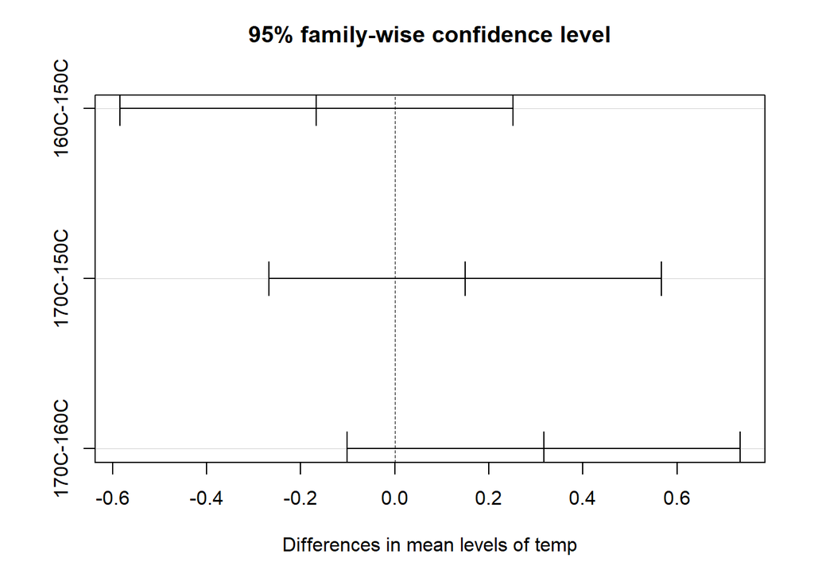

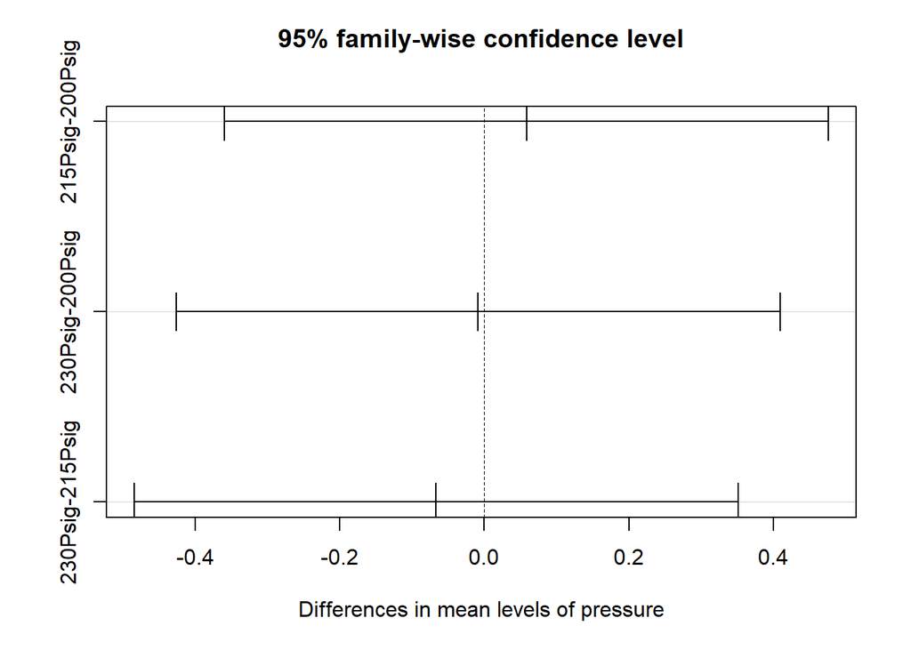

```r
plot(tukeys)
```

Pvalue is large for both pressure, and temperature at all conditions, so we accept null hypothesis that there is not much difference due to the changing conditions

```r
library(agricolae)
lsd <- LSD.test(chem.process.nointeraction.mod, c("temp", "pressure"), console=T)
```

```
##
## Study: chem.process.nointeraction.mod ~ c("temp", "pressure")
##
## LSD t Test for yield
##
## Mean Square Error:  0.07504274
##
## temp:pressure,  means and individual ( 95 %) CI
##
##                 yield       std r      LCL      UCL  Min  Max
## 150C:200Psig 90.43333 0.2516611 3 90.09165 90.77501 90.2 90.7
## 150C:215Psig 90.40000 0.2000000 3 90.05832 90.74168 90.2 90.6
## 160C:200Psig 90.20000 0.3605551 3 89.85832 90.54168 89.9 90.6
## 160C:230Psig 90.30000 0.2000000 3 89.95832 90.64168 90.1 90.5
## 170C:215Psig 90.66667 0.1527525 3 90.32499 91.00835 90.5 90.8
## 170C:230Psig 90.46667 0.4041452 3 90.12499 90.80835 90.1 90.9
##
## Alpha: 0.05 ; DF Error: 13
## Critical Value of t: 2.160369
##
## least Significant Difference: 0.4832107
##
## Treatments with the same letter are not significantly different.
##
##                 yield groups
## 170C:215Psig 90.66667      a
## 170C:230Psig 90.46667      a
## 150C:200Psig 90.43333      a
## 150C:215Psig 90.40000      a
## 160C:230Psig 90.30000      a
## 160C:200Psig 90.20000      a
```

```r
lsd
```

```
## $statistics
##      MSerror Df     Mean        CV  t.value       LSD
##   0.07504274 13 90.41111 0.3029929 2.160369 0.4832107
##
## $parameters
##         test p.ajusted        name.t ntr alpha
##   Fisher-LSD      none temp:pressure   6  0.05
##
## $means
##                 yield       std r      LCL      UCL  Min  Max   Q25  Q50   Q75
## 150C:200Psig 90.43333 0.2516611 3 90.09165 90.77501 90.2 90.7 90.30 90.4 90.55
## 150C:215Psig 90.40000 0.2000000 3 90.05832 90.74168 90.2 90.6 90.30 90.4 90.50
## 160C:200Psig 90.20000 0.3605551 3 89.85832 90.54168 89.9 90.6 90.00 90.1 90.35
## 160C:230Psig 90.30000 0.2000000 3 89.95832 90.64168 90.1 90.5 90.20 90.3 90.40
## 170C:215Psig 90.66667 0.1527525 3 90.32499 91.00835 90.5 90.8 90.60 90.7 90.75
## 170C:230Psig 90.46667 0.4041452 3 90.12499 90.80835 90.1 90.9 90.25 90.4 90.65
##
## $comparison
## NULL
##
## $groups
##                 yield groups
## 170C:215Psig 90.66667      a
## 170C:230Psig 90.46667      a
## 150C:200Psig 90.43333      a
## 150C:215Psig 90.40000      a
## 160C:230Psig 90.30000      a
## 160C:200Psig 90.20000      a
##
## attr(,"class")
## [1] "group"
```

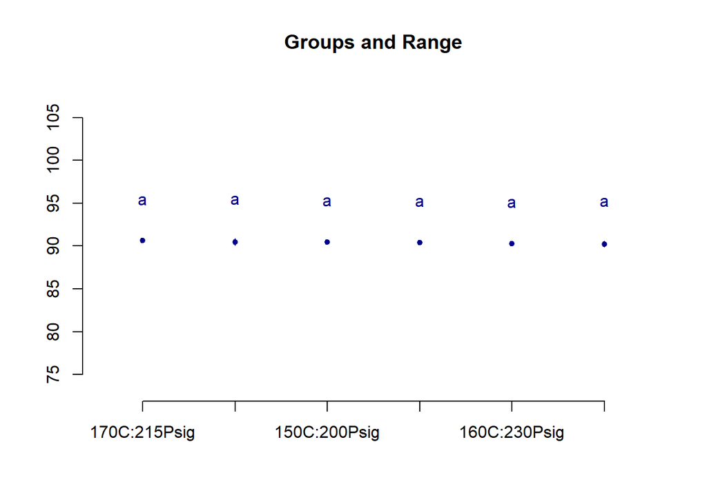

```r
plot(lsd)
```

```r
detach()
```

All terms generate almost the same yield, so we should choose the one which can be operatored at least cost. I would choose the one at 150C and 200Psig

## Question 2

setup data

```r
operator<- rep(c(1,2,3), each=8)
machine<- rep(c(1,2,3,4), each=2, times=3)

strength <- c(109, 110,110,115,108,109,110,108,110,112,110,111,111,109,114,112,116,114,112,115,114,119,120,117)

fiber <- data.frame(operator, machine, strength)

fiber$operator <-factor(operator, levels =c(1,2,3), labels=c("Op1", "Op2", "Op3"))
fiber$machine <-factor(machine, levels =c(1,2,3,4), labels=c("Mach1","Mach2","Mach3","Mach4"))
operator <-fiber$operator
machine <-fiber$machine

head(fiber)
```

|  | operator | machine | strength |
| --- | --- | --- | --- |
| 1 | Op1 | Mach1 | 109 |
| 2 | Op1 | Mach1 | 110 |
| 3 | Op1 | Mach2 | 110 |
| 4 | Op1 | Mach2 | 115 |
| 5 | Op1 | Mach3 | 108 |
| 6 | Op1 | Mach3 | 109 |

```r
str(fiber)
```

```
## 'data.frame':    24 obs. of  3 variables:
##  $ operator: Factor w/ 3 levels "Op1","Op2","Op3": 1 1 1 1 1 1 1 1 2 2 ...
##  $ machine : Factor w/ 4 levels "Mach1","Mach2",..: 1 1 2 2 3 3 4 4 1 1 ...
##  $ strength: num  109 110 110 115 108 109 110 108 110 112 ...
```

```r
attach(fiber)
```

a1. Plotting: boxplot of strength vs operator, strength vs machine, strength vs operator and machine, interaction plot

```r
tapply(strength, list(operator,machine), mean)
```

```
##     Mach1 Mach2 Mach3 Mach4
## Op1 109.5 112.5 108.5 109.0
## Op2 111.0 110.5 110.0 113.0
## Op3 115.0 113.5 116.5 118.5
```

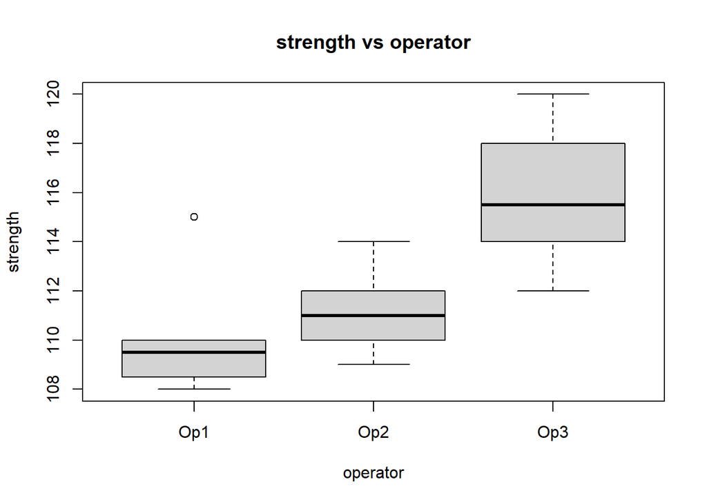

```r
boxplot(strength~operator, main="strength vs operator")
```

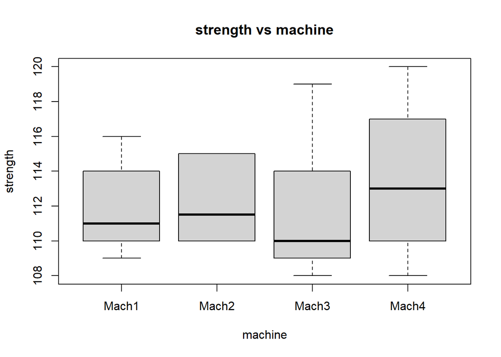

```r
boxplot(strength~machine, main="strength vs machine")
```

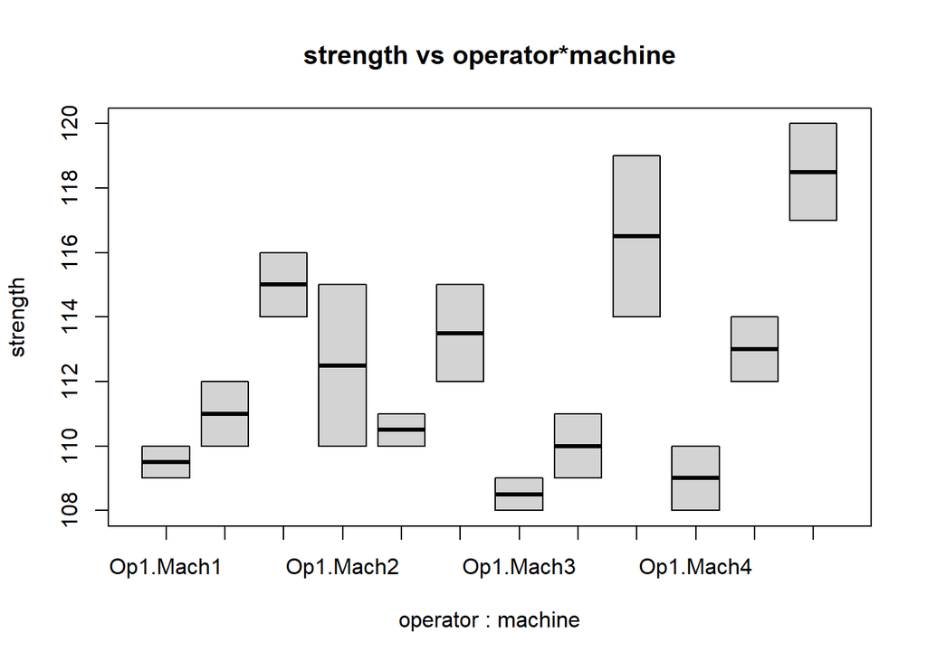

```r
boxplot(strength~operator*machine, main="strength vs operator*machine")
```

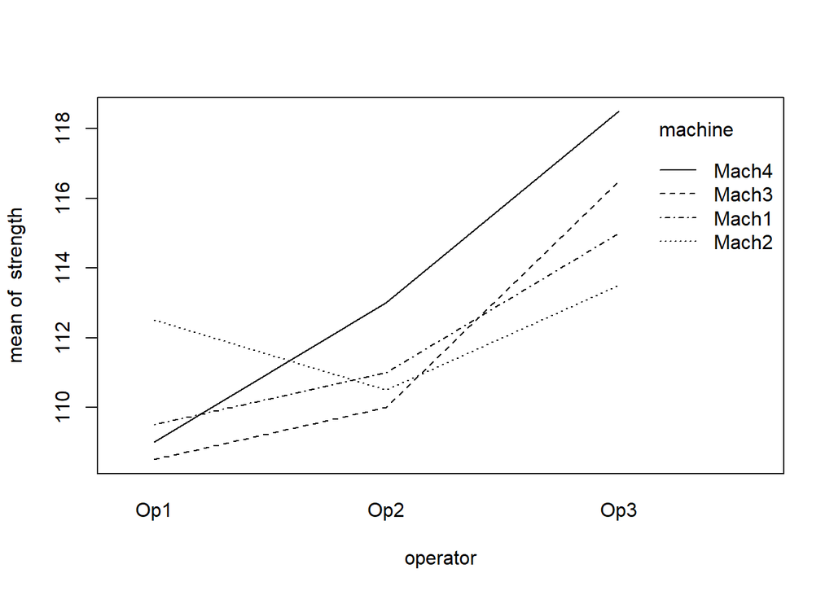

```r
interaction.plot(operator, machine, strength)
```

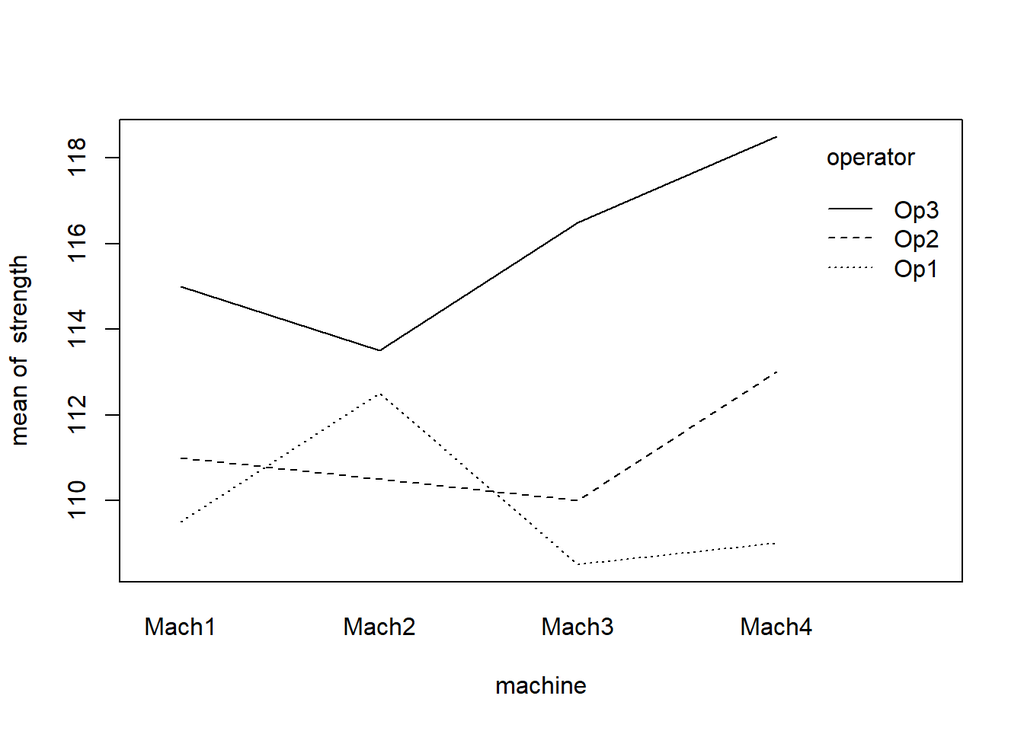

```r
interaction.plot(machine, operator, strength)
```

a2. Build a linear model using aov(). Print ANOVA output. Are main factors and interaction factor significant?

```r
fiber.mod <- aov(strength~operator*machine)
summary.aov(fiber.mod)
```

```
##                  Df Sum Sq Mean Sq F value   Pr(>F)
## operator          2 160.33   80.17  21.143 0.000117 ***
## machine           3  12.46    4.15   1.095 0.388753
## operator:machine  6  44.67    7.44   1.963 0.150681
## Residuals        12  45.50    3.79
## ---
## Signif. codes:  0 '***' 0.001 '**' 0.01 '*' 0.05 '.' 0.1 ' ' 1
```

```r
summary.lm(fiber.mod)
```

```
##
## Call:
## aov(formula = strength ~ operator * machine)
##
## Residuals:
##    Min     1Q Median     3Q    Max
##   -2.5   -1.0    0.0    1.0    2.5
##
## Coefficients:
##                            Estimate Std. Error t value Pr(>|t|)
## (Intercept)               1.095e+02  1.377e+00  79.527   <2e-16 ***
## operatorOp2               1.500e+00  1.947e+00   0.770   0.4560
## operatorOp3               5.500e+00  1.947e+00   2.825   0.0153 *
## machineMach2              3.000e+00  1.947e+00   1.541   0.1493
## machineMach3             -1.000e+00  1.947e+00  -0.514   0.6169
## machineMach4             -5.000e-01  1.947e+00  -0.257   0.8017
## operatorOp2:machineMach2 -3.500e+00  2.754e+00  -1.271   0.2278
## operatorOp3:machineMach2 -4.500e+00  2.754e+00  -1.634   0.1282
## operatorOp2:machineMach3  8.573e-14  2.754e+00   0.000   1.0000
## operatorOp3:machineMach3  2.500e+00  2.754e+00   0.908   0.3818
## operatorOp2:machineMach4  2.500e+00  2.754e+00   0.908   0.3818
## operatorOp3:machineMach4  4.000e+00  2.754e+00   1.453   0.1720
## ---
## Signif. codes:  0 '***' 0.001 '**' 0.01 '*' 0.05 '.' 0.1 ' ' 1
##
## Residual standard error: 1.947 on 12 degrees of freedom
## Multiple R-squared:  0.827,  Adjusted R-squared:  0.6684
## F-statistic: 5.214 on 11 and 12 DF,  p-value: 0.004136
```

```r
operator
```

```
##  [1] Op1 Op1 Op1 Op1 Op1 Op1 Op1 Op1 Op2 Op2 Op2 Op2 Op2 Op2 Op2 Op2 Op3 Op3 Op3
## [20] Op3 Op3 Op3 Op3 Op3
## Levels: Op1 Op2 Op3
```

```r
fiber.nointeraction.mod <- aov(strength~operator+machine)
anova(fiber.mod, fiber.nointeraction.mod)
```

|  | Res.Df | RSS | Df | Sum of Sq | F | Pr(>F) |
| --- | --- | --- | --- | --- | --- | --- |
| 1 | 12 | 45.50000 | NA | NA | NA | NA |
| 2 | 18 | 90.16667 | -6 | -44.66667 | 1.96337 | 0.1506807 |

Since P-value >.05, we accept null and reject Alternate. The interaction term is in-significant, so we can discard the interaction term. We take the partial model instead of full model

a3. Print out regression model with coefficients

```r
summary.lm(fiber.nointeraction.mod)
```

```
##
## Call:
## aov(formula = strength ~ operator + machine)
##
## Residuals:
##     Min      1Q  Median      3Q     Max
## -3.7500 -1.1250 -0.2917  0.5833  5.2500
##
## Coefficients:
##              Estimate Std. Error t value Pr(>|t|)
## (Intercept)  109.4167     1.1191  97.775  < 2e-16 ***
## operatorOp2    1.2500     1.1191   1.117    0.279
## operatorOp3    6.0000     1.1191   5.362 4.27e-05 ***
## machineMach2   0.3333     1.2922   0.258    0.799
## machineMach3  -0.1667     1.2922  -0.129    0.899
## machineMach4   1.6667     1.2922   1.290    0.213
## ---
## Signif. codes:  0 '***' 0.001 '**' 0.01 '*' 0.05 '.' 0.1 ' ' 1
##
## Residual standard error: 2.238 on 18 degrees of freedom
## Multiple R-squared:  0.6571, Adjusted R-squared:  0.5619
## F-statistic: 6.899 on 5 and 18 DF,  p-value: 0.00093
```

Intercept and Operator are both siginficant

```r
summary.lm(fiber.nointeraction.mod)
```

```
##
## Call:
## aov(formula = strength ~ operator + machine)
##
## Residuals:
##     Min      1Q  Median      3Q     Max
## -3.7500 -1.1250 -0.2917  0.5833  5.2500
##
## Coefficients:
##              Estimate Std. Error t value Pr(>|t|)
## (Intercept)  109.4167     1.1191  97.775  < 2e-16 ***
## operatorOp2    1.2500     1.1191   1.117    0.279
## operatorOp3    6.0000     1.1191   5.362 4.27e-05 ***
## machineMach2   0.3333     1.2922   0.258    0.799
## machineMach3  -0.1667     1.2922  -0.129    0.899
## machineMach4   1.6667     1.2922   1.290    0.213
## ---
## Signif. codes:  0 '***' 0.001 '**' 0.01 '*' 0.05 '.' 0.1 ' ' 1
##
## Residual standard error: 2.238 on 18 degrees of freedom
## Multiple R-squared:  0.6571, Adjusted R-squared:  0.5619
## F-statistic: 6.899 on 5 and 18 DF,  p-value: 0.00093
```

```r
summary.aov(fiber.nointeraction.mod)
```

```
##             Df Sum Sq Mean Sq F value   Pr(>F)
## operator     2 160.33   80.17  16.004 0.000101 ***
## machine      3  12.46    4.15   0.829 0.495098
## Residuals   18  90.17    5.01
## ---
## Signif. codes:  0 '***' 0.001 '**' 0.01 '*' 0.05 '.' 0.1 ' ' 1
```

It looks like the difference of mean is same for machine while it’s different for operator. We need to run Tukey’s test to see which one are different

### c. Under what condition would you operate this process

```r
tukeys <- TukeyHSD(fiber.nointeraction.mod)
tukeys
```

```
##   Tukey multiple comparisons of means
##     95% family-wise confidence level
##
## Fit: aov(formula = strength ~ operator + machine)
##
## $operator
##         diff       lwr      upr     p adj
## Op2-Op1 1.25 -1.606046 4.106046 0.5162537
## Op3-Op1 6.00  3.143954 8.856046 0.0001210
## Op3-Op2 4.75  1.893954 7.606046 0.0013473
##
## $machine
##                   diff       lwr      upr     p adj
## Mach2-Mach1  0.3333333 -3.318768 3.985435 0.9937651
## Mach3-Mach1 -0.1666667 -3.818768 3.485435 0.9992035
## Mach4-Mach1  1.6666667 -1.985435 5.318768 0.5807291
## Mach3-Mach2 -0.5000000 -4.152102 3.152102 0.9796977
## Mach4-Mach2  1.3333333 -2.318768 4.985435 0.7334070
## Mach4-Mach3  1.8333333 -1.818768 5.485435 0.5043547
```

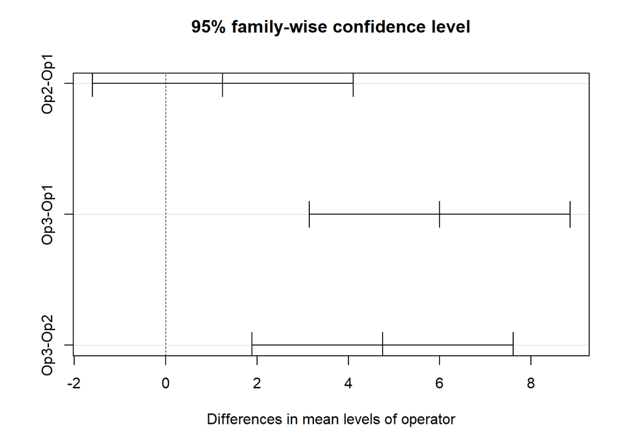

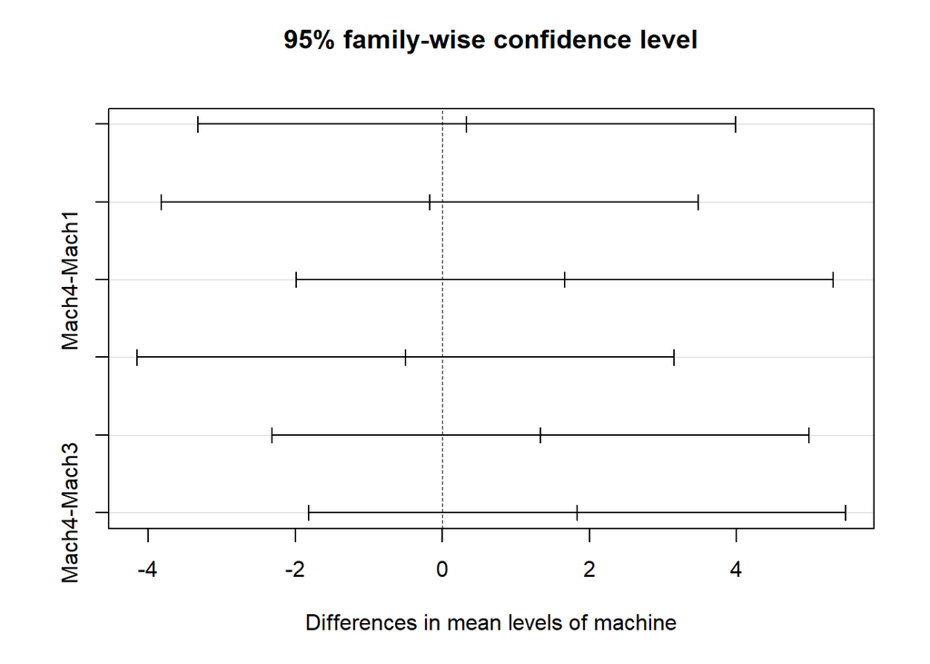

```r
plot(tukeys)
```

```r
library(agricolae)
lsd <- LSD.test(fiber.nointeraction.mod, c("operator", "machine"), console=T)
```

```
##
## Study: fiber.nointeraction.mod ~ c("operator", "machine")
##
## LSD t Test for strength
##
## Mean Square Error:  5.009259
##
## operator:machine,  means and individual ( 95 %) CI
##
##           strength       std r      LCL      UCL Min Max
## Op1:Mach1    109.5 0.7071068 2 106.1751 112.8249 109 110
## Op1:Mach2    112.5 3.5355339 2 109.1751 115.8249 110 115
## Op1:Mach3    108.5 0.7071068 2 105.1751 111.8249 108 109
## Op1:Mach4    109.0 1.4142136 2 105.6751 112.3249 108 110
## Op2:Mach1    111.0 1.4142136 2 107.6751 114.3249 110 112
## Op2:Mach2    110.5 0.7071068 2 107.1751 113.8249 110 111
## Op2:Mach3    110.0 1.4142136 2 106.6751 113.3249 109 111
## Op2:Mach4    113.0 1.4142136 2 109.6751 116.3249 112 114
## Op3:Mach1    115.0 1.4142136 2 111.6751 118.3249 114 116
## Op3:Mach2    113.5 2.1213203 2 110.1751 116.8249 112 115
## Op3:Mach3    116.5 3.5355339 2 113.1751 119.8249 114 119
## Op3:Mach4    118.5 2.1213203 2 115.1751 121.8249 117 120
##
## Alpha: 0.05 ; DF Error: 18
## Critical Value of t: 2.100922
##
## least Significant Difference: 4.702152
##
## Treatments with the same letter are not significantly different.
##
##           strength groups
## Op3:Mach4    118.5      a
## Op3:Mach3    116.5     ab
## Op3:Mach1    115.0    abc
## Op3:Mach2    113.5    bcd
## Op2:Mach4    113.0   bcde
## Op1:Mach2    112.5   bcde
## Op2:Mach1    111.0    cde
## Op2:Mach2    110.5    cde
## Op2:Mach3    110.0     de
## Op1:Mach1    109.5     de
## Op1:Mach4    109.0     de
## Op1:Mach3    108.5      e
```

```r
lsd
```

```
## $statistics
##    MSerror Df     Mean       CV  t.value      LSD
##   5.009259 18 112.2917 1.993147 2.100922 4.702152
##
## $parameters
##         test p.ajusted           name.t ntr alpha
##   Fisher-LSD      none operator:machine  12  0.05
##
## $means
##           strength       std r      LCL      UCL Min Max    Q25   Q50    Q75
## Op1:Mach1    109.5 0.7071068 2 106.1751 112.8249 109 110 109.25 109.5 109.75
## Op1:Mach2    112.5 3.5355339 2 109.1751 115.8249 110 115 111.25 112.5 113.75
## Op1:Mach3    108.5 0.7071068 2 105.1751 111.8249 108 109 108.25 108.5 108.75
## Op1:Mach4    109.0 1.4142136 2 105.6751 112.3249 108 110 108.50 109.0 109.50
## Op2:Mach1    111.0 1.4142136 2 107.6751 114.3249 110 112 110.50 111.0 111.50
## Op2:Mach2    110.5 0.7071068 2 107.1751 113.8249 110 111 110.25 110.5 110.75
## Op2:Mach3    110.0 1.4142136 2 106.6751 113.3249 109 111 109.50 110.0 110.50
## Op2:Mach4    113.0 1.4142136 2 109.6751 116.3249 112 114 112.50 113.0 113.50
## Op3:Mach1    115.0 1.4142136 2 111.6751 118.3249 114 116 114.50 115.0 115.50
## Op3:Mach2    113.5 2.1213203 2 110.1751 116.8249 112 115 112.75 113.5 114.25
## Op3:Mach3    116.5 3.5355339 2 113.1751 119.8249 114 119 115.25 116.5 117.75
## Op3:Mach4    118.5 2.1213203 2 115.1751 121.8249 117 120 117.75 118.5 119.25
##
## $comparison
## NULL
##
## $groups
##           strength groups
## Op3:Mach4    118.5      a
## Op3:Mach3    116.5     ab
## Op3:Mach1    115.0    abc
## Op3:Mach2    113.5    bcd
## Op2:Mach4    113.0   bcde
## Op1:Mach2    112.5   bcde
## Op2:Mach1    111.0    cde
## Op2:Mach2    110.5    cde
## Op2:Mach3    110.0     de
## Op1:Mach1    109.5     de
## Op1:Mach4    109.0     de
## Op1:Mach3    108.5      e
##
## attr(,"class")
## [1] "group"
```

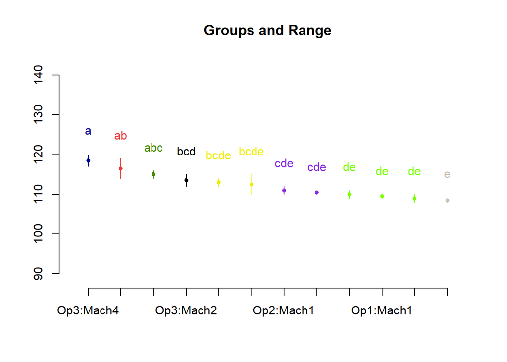

```r
plot(lsd)
```

Operator3 and machine 4 appears to give the best strength

## Question 3.

### a. create data frame with days and solution and growth as response variable

```r
solution <-rep(c(1,2,3), each=4)
days <-  rep(c(1,2,3,4), each=3)
solution <- factor(solution, levels=c(1,2,3), labels = c("Sol1", "Sol2", "Sol3"))
days <- factor(days, levels =c(1,2,3,4), labels = c("Day1", "Day2", "Day3", "Day4"))

growth<-c(13,22,18,39,16,24,17,44,5,4,1,22)

powder <-data.frame(solution, days, growth)

head(powder)
```

|  | solution | days | growth |
| --- | --- | --- | --- |
| 1 | Sol1 | Day1 | 13 |
| 2 | Sol1 | Day1 | 22 |
| 3 | Sol1 | Day1 | 18 |
| 4 | Sol1 | Day2 | 39 |
| 5 | Sol2 | Day2 | 16 |
| 6 | Sol2 | Day2 | 24 |

```r
str(powder)
```

```
## 'data.frame':    12 obs. of  3 variables:
##  $ solution: Factor w/ 3 levels "Sol1","Sol2",..: 1 1 1 1 2 2 2 2 3 3 ...
##  $ days    : Factor w/ 4 levels "Day1","Day2",..: 1 1 1 2 2 2 3 3 3 4 ...
##  $ growth  : num  13 22 18 39 16 24 17 44 5 4 ...
```

```r
attach(powder)
```

Any evidence that the solution affect bacteria growth

```r
length(growth)
```

```
## [1] 12
```

```r
length(solution)
```

```
## [1] 12
```

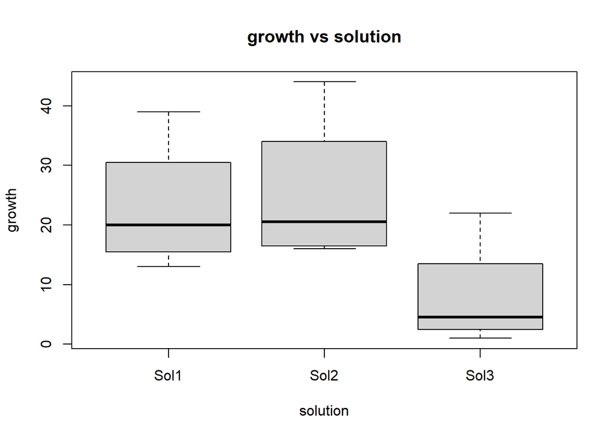

```r
boxplot(growth~solution, main="growth vs solution")
```

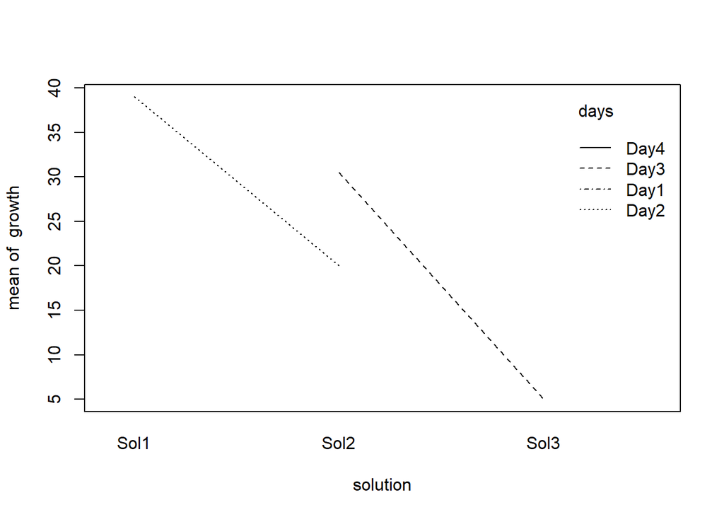

```r
interaction.plot(solution, days, growth)
```

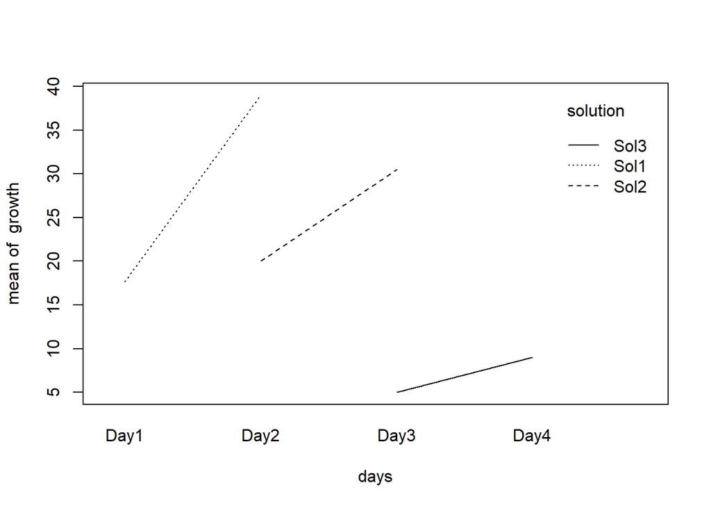

```r
interaction.plot(days, solution, growth)
```

```r
powder.mod <- aov(growth~solution*days)
summary.aov(powder.mod)
```

```
##             Df Sum Sq Mean Sq F value Pr(>F)
## solution     2  703.5   351.8   3.036  0.123
## days         3  463.6   154.5   1.334  0.348
## Residuals    6  695.2   115.9
```

```r
summary.lm(powder.mod)
```

```
##
## Call:
## aov(formula = growth ~ solution * days)
##
## Residuals:
##     Min      1Q  Median      3Q     Max
## -13.500  -4.750   0.000   4.083  13.500
##
## Coefficients: (6 not defined because of singularities)
##                       Estimate Std. Error t value Pr(>|t|)
## (Intercept)             17.667      6.215   2.843   0.0295 *
## solutionSol2           -19.000     13.183  -1.441   0.1996
## solutionSol3           -44.500     18.644  -2.387   0.0543 .
## daysDay2                21.333     12.429   1.716   0.1369
## daysDay3                31.833     16.442   1.936   0.1010
## daysDay4                35.833     20.611   1.739   0.1328
## solutionSol2:daysDay2       NA         NA      NA       NA
## solutionSol3:daysDay2       NA         NA      NA       NA
## solutionSol2:daysDay3       NA         NA      NA       NA
## solutionSol3:daysDay3       NA         NA      NA       NA
## solutionSol2:daysDay4       NA         NA      NA       NA
## solutionSol3:daysDay4       NA         NA      NA       NA
## ---
## Signif. codes:  0 '***' 0.001 '**' 0.01 '*' 0.05 '.' 0.1 ' ' 1
##
## Residual standard error: 10.76 on 6 degrees of freedom
## Multiple R-squared:  0.6267, Adjusted R-squared:  0.3156
## F-statistic: 2.015 on 5 and 6 DF,  p-value: 0.2093
```

```r
powder.nointeraction.mod <- aov(growth~solution+days)
anova(powder.mod, powder.nointeraction.mod)
```

|  | Res.Df | RSS | Df | Sum of Sq | F | Pr(>F) |
| --- | --- | --- | --- | --- | --- | --- |
| 1 | 6 | 695.1667 | NA | NA | NA | NA |
| 2 | 6 | 695.1667 | 0 | 0 | NA | NA |

### b. Perform a TukeyHSD to compare solution treatment means

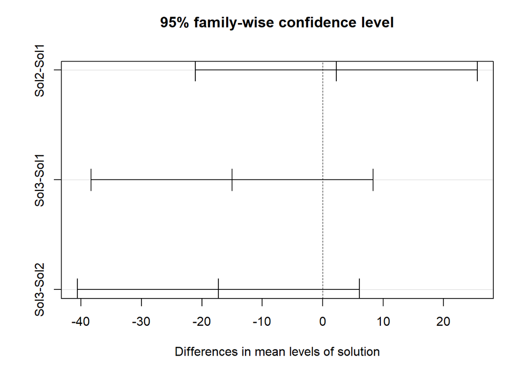

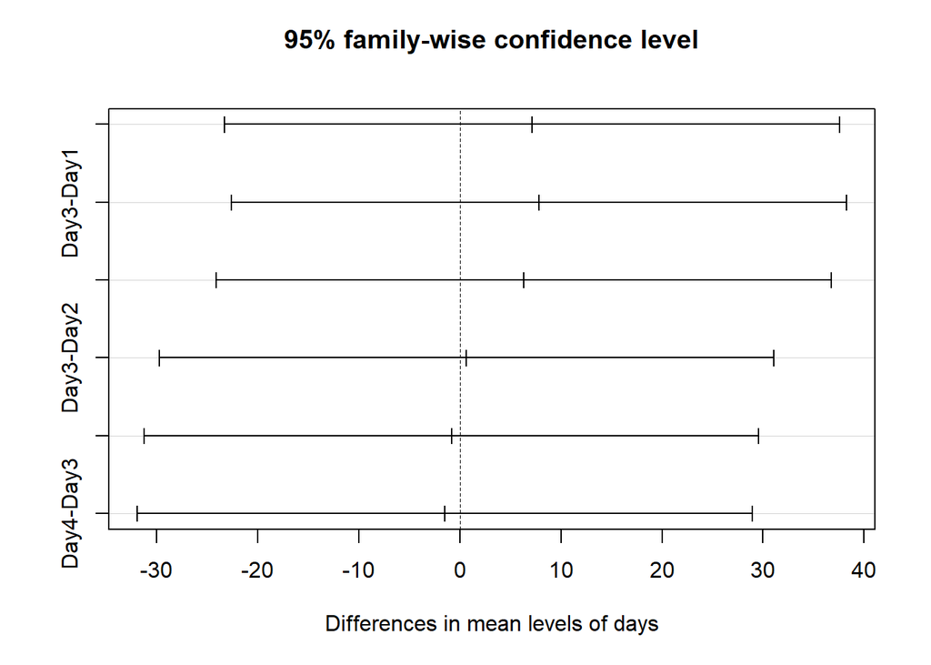

```r
tukeys <- TukeyHSD(powder.nointeraction.mod)
plot(tukeys)
```

Difference of mean is the same so the solution or days doesn’t affect much of the bacterial growth

```r
lsd <- LSD.test(powder.nointeraction.mod, c("solution", "days"), console = T)
```

```
##
## Study: powder.nointeraction.mod ~ c("solution", "days")
##
## LSD t Test for growth
##
## Mean Square Error:  115.8611
##
## solution:days,  means and individual ( 95 %) CI
##
##             growth       std r        LCL      UCL Min Max
## Sol1:Day1 17.66667  4.509250 3   2.460262 32.87307  13  22
## Sol1:Day2 39.00000        NA 1  12.661735 65.33827  39  39
## Sol2:Day2 20.00000  5.656854 2   1.376034 38.62397  16  24
## Sol2:Day3 30.50000 19.091883 2  11.876034 49.12397  17  44
## Sol3:Day3  5.00000        NA 1 -21.338265 31.33827   5   5
## Sol3:Day4  9.00000 11.357817 3  -6.206405 24.20640   1  22
##
## Alpha: 0.05 ; DF Error: 6
## Critical Value of t: 2.446912
##
## Groups according to probability of means differences and alpha level( 0.05 )
##
## Treatments with the same letter are not significantly different.
##
##             growth groups
## Sol1:Day2 39.00000      a
## Sol2:Day3 30.50000      a
## Sol2:Day2 20.00000      a
## Sol1:Day1 17.66667      a
## Sol3:Day4  9.00000      a
## Sol3:Day3  5.00000      a
```

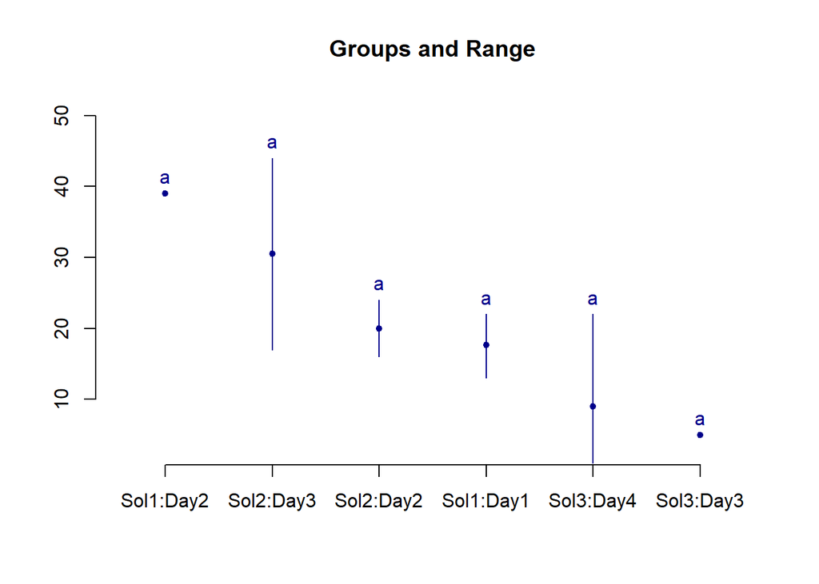

```r
plot(lsd)
```

The solution and days doesn’t appear to have much affect on growth.

### c. Check assumptions of the residuals

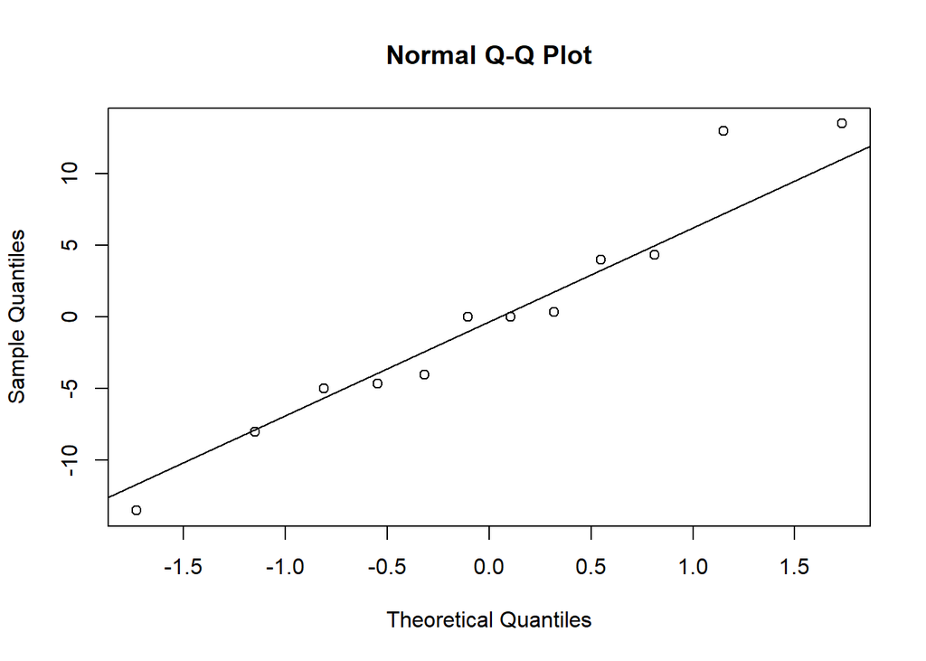

```r
res <- residuals(powder.nointeraction.mod)

qqnorm(res)
qqline(res)
```

```r
shapiro.test(res)
```

```
##
##  Shapiro-Wilk normality test
##
## data:  res
## W = 0.95242, p-value = 0.6726
```

```r
#check variance
bartlett.test(res~solution)
```

```
##
##  Bartlett test of homogeneity of variances
##
## data:  res by solution
## Bartlett's K-squared = 2.8626, df = 2, p-value = 0.239
```

```r
bartlett.test(res~days)
```

```
##
##  Bartlett test of homogeneity of variances
##
## data:  res by days
## Bartlett's K-squared = 3.3249, df = 3, p-value = 0.3442
```

The data is normal and variance is equal.